# # Plants_Seedling_Classification

**Background and Context**

In recent times, the field of agriculture has been in urgent need of modernizing, since the amount of manual work people need to put in to check if plants are growing correctly is still highly extensive. Despite several advances in agricultural technology, people working in the agricultural industry still need to have the ability to sort and recognize different plants and weeds, which takes a lot of time and effort in the long term.

The potential is ripe for this trillion-dollar industry to be greatly impacted by technological innovations that cut down on the requirement for manual labor, and this is where Artificial Intelligence can benefit the workers in this field, as the time and energy required to identify plant seedlings will be greatly shortened by the use of AI and Deep Learning. The ability to do so far more efficiently and even more effectively than experienced manual labor could lead to better crop yields, the freeing up of human involvement for higher-order agricultural decision making, and in the long term will result in more sustainable environmental practices in agriculture as well.

**Objective**

The Aarhus University Signal Processing group, in collaboration with the University of Southern Denmark, has provided the data containing images of unique plants belonging to 12 different species. You being a data scientist, need to build a Convolutional Neural Network model which would classify the plant seedlings into their respective 12 categories.

**Data Description**

This dataset contains images of unique plants belonging to 12 different species. The data file names are: images.npy Label.csv Due to the large volume of data, the images were converted to numpy arrays and stored in images.npy file and the corresponding labels are also put into Labels.csv so that you can work on the data/project seamlessly without having to worry about the high data volume. The goal of the project is to create a classifier capable of determining a plant's species from an image. List of Plant species

- Black-grass
- Charlock
- Cleavers
- Common Chickweed
- Common Wheat
- Fat Hen
- Loose Silky-bent
- Maize
- Scentless Mayweed
- Shepherds Purse
- Small-flowered Cranesbill
- Sugar beet

```python
# import the library
import numpy as np
import pandas as pd

import matplotlib.pyplot as plt
import seaborn as sns

import tensorflow as tf

from tensorflow.keras import backend as K

import cv2 as cv2
from google.colab.patches import cv2_imshow

from sklearn.model_selection import train_test_split
from sklearn.metrics import classification_report, confusion_matrix

# Import VGG16 for transfer learning
from tensorflow.keras.applications.vgg16 import VGG16

import warnings
warnings.filterwarnings('ignore')
```

# Problem Definition and Data Overview

- Define the problem statement - Read the dataset properly - Check the shape of the data

```python
# define the file paths
images_file_path ='/content/images.npy'
labels_file_path = '/content/Labels.csv'
```

```python
# load the data
images_data= np.load(images_file_path)
labels_data = pd.read_csv(labels_file_path)
```

```python
# Shape of the data
images_data.shape, labels_data.shape

# Dataset contains 4750 color images with size (128,128) and three channels (RGB)
```

```
((4750, 128, 128, 3), (4750, 1))
```

```python
# size of the image
img_width = images_data.shape[1]
img_height = images_data.shape[2]
channel = images_data.shape[3]

print('Image Size:',(img_width, img_height, channel))
```

```
Image Size: (128, 128, 3)
```

# Perform an Exploratory Data Analysis and get the insights on the images

- Plot random images from each of the classes and print their corresponding labels. - Count Plot for each category - Key meaningful observations from EDA

```python
# list of different species
categories = ['Small-flowered Cranesbill',
       'Fat Hen',
       'Shepherds Purse',
       'Common wheat',
       'Common Chickweed',
       'Charlock',
       'Cleavers',
       'Scentless Mayweed',
       'Sugar beet',
       'Maize',
       'Black-grass',
       'Loose Silky-bent']

categories.sort()

num_categories = len(categories)
print('No of plant category:', num_categories)
```

```
No of plant category: 12
```

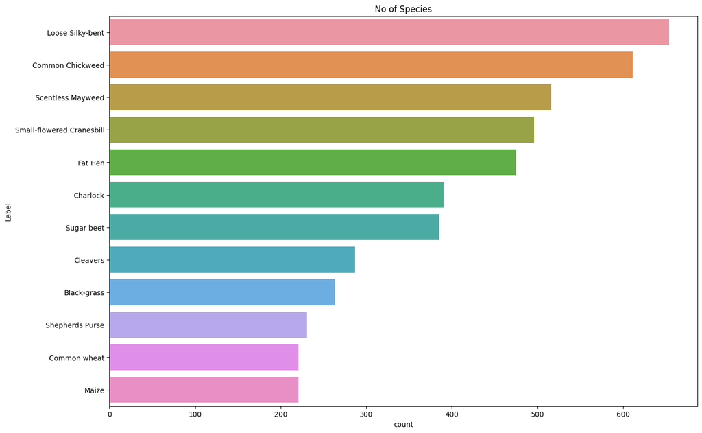

```python
# get the counts of each species
species_count = labels_data.value_counts()

df_species_count = pd.DataFrame(species_count, columns=['count'])

df_species_count.reset_index(inplace=True)

plt.figure(figsize=(15,10))
plt.title('No of Species')

# draw the plot
sns.barplot(df_species_count, x='count', y='Label')

plt.show();
```

- Plant species are not equaly distibuted i.e. dataset is imbalanced.
- Loose Silky-bent are maximum in dataset.
- Cleavers,Black-grass, Shepherds Purse, Common wheat and Maize having less than 300 entry in dataset.

```python
# get index for each category

unique_category_index = []

for category in categories:

  # get only single from list of index for same category
  category_index = (np.where(labels_data['Label'] == category))[0]
  category_index = np.random.choice(category_index)

  # append to list
  unique_category_index.append(category_index)

print('Each category index: ', unique_category_index)
```

```
Each category index:  [3853, 2211, 2634, 1675, 1316, 823, 4475, 3773, 2821, 1113, 137, 3470]
```

[figure not shown]

```python
# get index for each category
unique_category_index = []

for category in categories:

  # get only single from list of index for same category
  category_index = (np.where(labels_data['Label'] == category))[0]
  category_index = np.random.choice(category_index)

  # append to list
  unique_category_index.append(category_index)

#print('[INFO] Each category index: ', unique_category_index)

#print('[INFO] Plot the images for each category...')
#print('\n')
plt.figure(figsize=(10,10))
for index, image_number in enumerate(unique_category_index):
  ax = plt.subplot(3, 4, index + 1)
  plt.imshow(images_data[image_number], cmap='Greys_r')
  plt.title(labels_data.values[image_number][0])
  plt.axis('off')


# display the images
plt.show()
```

# Data Pre-processing

- Convert the BGR images to RGB images - Resize the images - Plot the images before and after the pre-processing steps - Split the data into train and test - Encode the target variables - Apply the normalization
- Convert the BGR images to RGB images

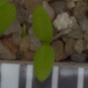

```python
# get any image
image = images_data[1435]

cv2_imshow(image)
```

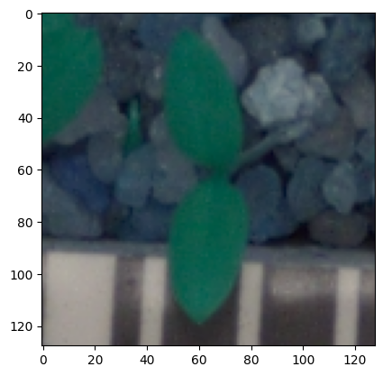

```python
plt.imshow(image);
```

- We can observe that the images are being shown in different colors when plotted with openCV and matplotlib as OpenCV reads images in BGR format and this shows that the given numpy arrays were generated from the original images using OpenCV.
- Now we will convert these BGR images to RGB images so we could interpret them easily.

```python
# Convert BGR images to RGB

for i in range(len(images_data)):
  images_data[i] = cv2.cvtColor(images_data[i], cv2.COLOR_BGR2RGB)
```

- Resize the Images

```python
# Resize the image to 64 * 64 to keep the same aspect ratio

resized_image = []
r = 64.0 / image.shape[1]
dim = (64, int(image.shape[0] * r))

for i in range(len(images_data)):
  resized_image.append(cv2.resize(images_data[i], dim, cv2.INTER_AREA))
```

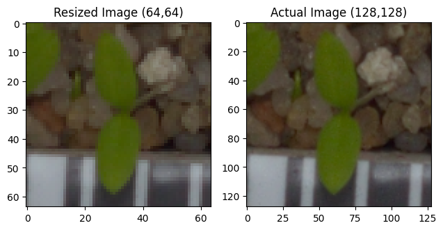

```python
fig, (ax1,ax2) = plt.subplots(1,2)

ax1.imshow(resized_image[1435])
ax1.set_title('Resized Image (64,64)')


ax2.imshow(images_data[1435])
ax2.set_title('Actual Image (128,128)')

plt.tight_layout()
plt.show();
```

- Apply the blur on resized images

```
[INFO] Applying Average Blur..
```

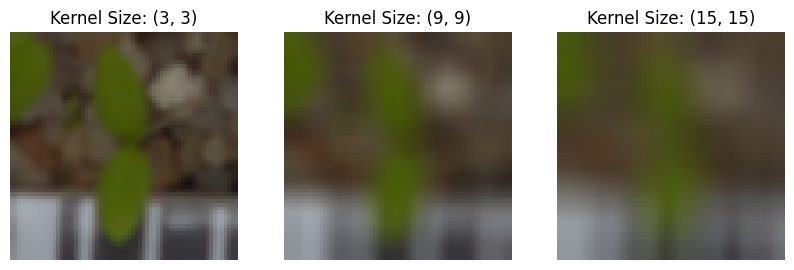

```python
plt.figure(figsize=(10,10))

# initilize the differnt kernel size to see the effect
kernelSizes = [(3,3), (9,9), (15,15)]

print('[INFO] Applying Average Blur..')
for i, (kX,kY) in enumerate(kernelSizes):
  ax = plt.subplot(1,3, i+1)
  blurred = cv2.blur(resized_image[1435], (kX,kY))
  plt.imshow(blurred)
  plt.title('Kernel Size: {}'.format((kX,kY)))

  plt.axis('off')
```

- As size of the kernel increases, image is getting more blurred progresively and lose the egdes of important structural of the images.
- Let's apply the GaussianBlur and see the effect.

```
[INFO] Applying Gaussian Blur..
```

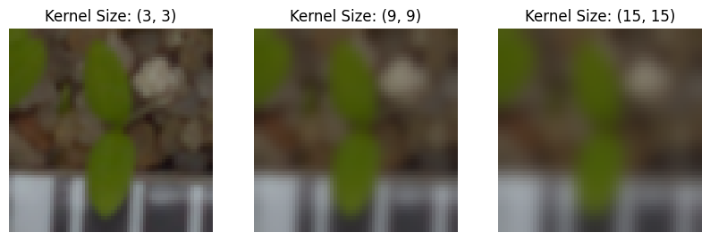

```python
plt.figure(figsize=(10,10))

# initilize the differnt kernel size to see the effect
kernelSizes = [(3,3), (9,9), (15,15)]

print('[INFO] Applying Gaussian Blur..')
for i, (kX,kY) in enumerate(kernelSizes):
  ax = plt.subplot(1,3, i+1)
  blurred = cv2.GaussianBlur(resized_image[1435], (kX,kY), sigmaX =  0)
  plt.imshow(blurred)
  plt.title('Kernel Size: {}'.format((kX,kY)))

  plt.axis('off')
```

- GaussianBlur is able to perform better than average blur to identify the features as kernel size increased.

```python
# spliting the dataset

# split the data into temp and test dataset
tempX, testX, tempY, testY = train_test_split(np.array(resized_image), labels_data, test_size=.1, random_state=42, stratify=labels_data)

# split the data into train and validateion
trainX, valX, trainY, valY = train_test_split(np.array(tempX), tempY, test_size=.1, random_state=42, stratify=tempY)
```

```python
print(trainX.shape,trainY.shape)
print(valX.shape, valY.shape)
print(testX.shape, testY.shape)
```

```
(3847, 64, 64, 3) (3847, 1)
(428, 64, 64, 3) (428, 1)
(475, 64, 64, 3) (475, 1)
```

```python
# Normalized the images
trainX_normalized = trainX.astype('float32') / 255.0
valX_normalized = valX.astype('float32') / 255.0
testX_normalized = testX.astype('float32') / 255.0
```

```python
# encode the target variables
from sklearn.preprocessing import LabelBinarizer

# Storing the LabelBinarizer function in lb variable
lb = LabelBinarizer()

# Applying fit_transform on train target variable
trainY_encoded = lb.fit_transform(trainY)

# apply the transform to validation and test
valY_encoded = lb.transform(valY)
testY_encoded = lb.transform(testY)
```

# Model building

- Build Convolution Neural Network - Evaluate the model on different performance metrics and comment on the performance. For example precision, recall, accuracy. - Plot confusion matrix

```python
# Build the MiniVGGNet network
# first CONV => RELU => CONV => RELU => POOL layer set
class MiniVGGNet:
  def build(width, height, depth, classes):

    inputShape = (height, width, depth)
    chanDim = -1

    if K.image_data_format() == 'channels_first':
      inputShape = (depth, height, width)

    model = tf.keras.models.Sequential()

    # features extraction
    model.add(tf.keras.layers.Conv2D(32, (3,3), padding='same', activation='relu', input_shape = inputShape))
    model.add(tf.keras.layers.BatchNormalization(axis=chanDim))
    model.add(tf.keras.layers.Conv2D(32, (3,3), padding='same', activation='relu'))
    model.add(tf.keras.layers.BatchNormalization(axis=chanDim))
    model.add(tf.keras.layers.MaxPooling2D(pool_size=(2,2)))
    model.add(tf.keras.layers.Dropout(.25))

    model.add(tf.keras.layers.Conv2D(64, (3,3), padding='same', activation='relu'))
    model.add(tf.keras.layers.BatchNormalization(axis=chanDim))
    model.add(tf.keras.layers.Conv2D(64, (3,3), padding='same', activation='relu'))
    model.add(tf.keras.layers.BatchNormalization(axis=chanDim))
    model.add(tf.keras.layers.MaxPooling2D(pool_size=(2,2)))
    model.add(tf.keras.layers.Dropout(.5))

    # classifier
    model.add(tf.keras.layers.Flatten())
    model.add(tf.keras.layers.Dense(512, activation='relu'))
    model.add(tf.keras.layers.BatchNormalization())
    model.add(tf.keras.layers.Dense(classes,activation='softmax'))

    return model
```

```python
# define the SGD optimizer
opt = tf.keras.optimizers.SGD(learning_rate=0.1, momentum=0.9)

# build the model
model = MiniVGGNet.build(width=64, height=64, depth=3, classes=num_categories)

# compile the MiniVGGNet network
model.compile(optimizer=opt, loss='categorical_crossentropy', metrics=['accuracy'])

model.summary()
```

```
Model: "sequential"
_________________________________________________________________
 Layer (type)                Output Shape              Param #
=================================================================
 conv2d (Conv2D)             (None, 64, 64, 32)        896

 batch_normalization (Batch  (None, 64, 64, 32)        128
 Normalization)

 conv2d_1 (Conv2D)           (None, 64, 64, 32)        9248

 batch_normalization_1 (Bat  (None, 64, 64, 32)        128
 chNormalization)

 max_pooling2d (MaxPooling2  (None, 32, 32, 32)        0
 D)

 dropout (Dropout)           (None, 32, 32, 32)        0

 conv2d_2 (Conv2D)           (None, 32, 32, 64)        18496

 batch_normalization_2 (Bat  (None, 32, 32, 64)        256
 chNormalization)

 conv2d_3 (Conv2D)           (None, 32, 32, 64)        36928

 batch_normalization_3 (Bat  (None, 32, 32, 64)        256
 chNormalization)

 max_pooling2d_1 (MaxPoolin  (None, 16, 16, 64)        0
 g2D)

 dropout_1 (Dropout)         (None, 16, 16, 64)        0

 flatten (Flatten)           (None, 16384)             0

 dense (Dense)               (None, 512)               8389120

 batch_normalization_4 (Bat  (None, 512)               2048
 chNormalization)

 dense_1 (Dense)             (None, 12)                6156

=================================================================
Total params: 8463660 (32.29 MB)
Trainable params: 8462252 (32.28 MB)
Non-trainable params: 1408 (5.50 KB)
_________________________________________________________________
```

```python
# fit the model
history = model.fit(trainX_normalized, trainY_encoded, validation_data=(valX_normalized,valY_encoded), batch_size=64, epochs=20, verbose=1)
```

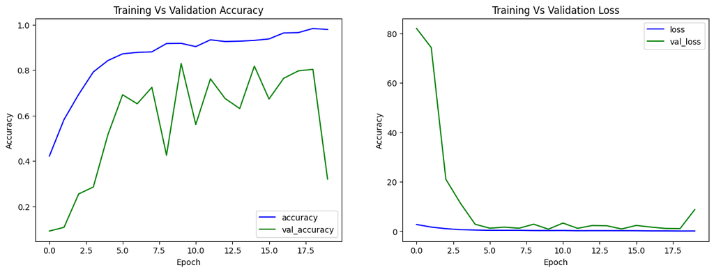

```python
# Analysis the results
fig, (ax1,ax2) = plt.subplots(1,2, figsize=(15,5))

# plot training vs validation accuracy
ax1.plot(np.arange(0,20), history.history['accuracy'], label='accuracy', color='blue')
ax1.plot(np.arange(0,20), history.history['val_accuracy'], label='val_accuracy', color='green')
ax1.set_title('Training Vs Validation Accuracy')
ax1.set_xlabel('Epoch')
ax1.set_ylabel('Accuracy')
ax1.legend(loc='lower right')

# plot training vs validation loss
ax2.plot(np.arange(0,20), history.history['loss'], label='loss', color='blue')
ax2.plot(np.arange(0,20), history.history['val_loss'],label='val_loss', color='green')
ax2.set_title('Training Vs Validation Loss')
ax2.set_xlabel('Epoch')
ax2.set_ylabel('Accuracy')
ax2.legend()

plt.show();
```

- We can see from the above plot that the training accuracy of the model is good but the validation accuracy is not good.
- The model seems to overfit on the data.

```python
# evaluate the model on test data:
accuracy = model.evaluate(testX_normalized, testY_encoded, verbose=2)
```

```
15/15 - 0s - loss: 8.3717 - accuracy: 0.3158 - 394ms/epoch - 26ms/step
```

- Model is performing good in training data set but poor in validation data set which shown that model is overfitting.
- Model having only 31% accuracy on unseen data.

```python
# predict the species catagories
y_pred = model.predict(testX_normalized)
```

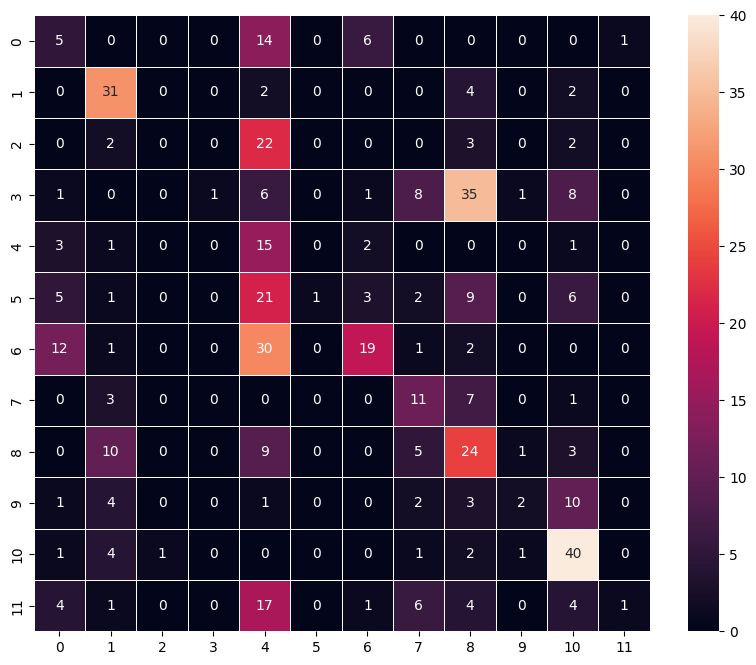

```python
confusion_matrix  = confusion_matrix(np.argmax(testY_encoded,axis=1), np.argmax(y_pred,axis=1))
f, ax = plt.subplots(figsize=(10, 8))
sns.heatmap(
    confusion_matrix,
    annot=True,
    linewidths=.4,
    fmt="d",
    square=True,
    ax=ax
)
plt.show()
```

# Model Performance Improvement and Final Model Selection

- Build another model using data augmentation to overcome the imbalance problem. - Evaluate the model on different performance metrics and comment on the performance. - Plot confusion matrix - Choose the best model from the ones built with proper reasoning.

```python
# Clearing backend
from tensorflow.keras import backend
backend.clear_session()

# Fixing the seed for random number generators
import random
np.random.seed(42)
random.seed(42)
tf.random.set_seed(42)
```

```python
# set the Data augementation layers
data_augmentation = tf.keras.Sequential([
    tf.keras.layers.RandomFlip("horizontal", input_shape=(64,64,3)),
    tf.keras.layers.RandomRotation(0.1),
    tf.keras.layers.RandomZoom(0.1)
])
```

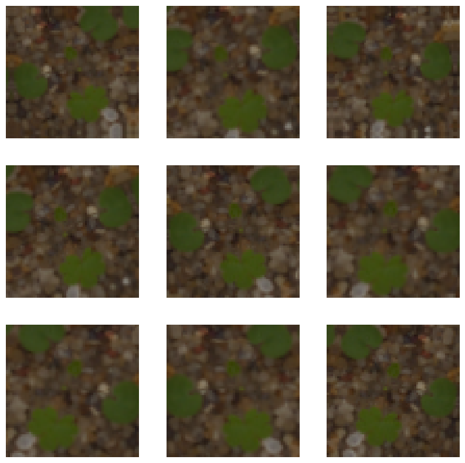

```python
# Add the image to a batch.
image = tf.cast(tf.expand_dims(resized_image[1], 0), tf.float32)

# View the data augumented image for one species
plt.figure(figsize=(10,10))
for i in range(9):
  augumented_images = data_augmentation(image)
  ax = plt.subplot(3, 3, i+1)
  plt.imshow(augumented_images[0].numpy().astype('uint8'))
  plt.axis('off')
```

```python
# Build the MiniVGGNet with data augementation network
# first CONV => RELU => CONV => RELU => POOL layer set
class MiniVGGNetWithDataAugumentation:
  def build(width, height, depth, classes):

    inputShape = (height, width, depth)
    chanDim = -1

    if K.image_data_format() == 'channels_first':
      inputShape = (depth, height, width)

    model = tf.keras.models.Sequential()

    # declare the data augumentation
    data_augmentation

    # features extraction
    model.add(tf.keras.layers.Conv2D(32, (3,3), padding='same', activation='relu', input_shape = inputShape))
    model.add(tf.keras.layers.BatchNormalization(axis=chanDim))
    model.add(tf.keras.layers.Conv2D(32, (3,3), padding='same', activation='relu'))
    model.add(tf.keras.layers.BatchNormalization(axis=chanDim))
    model.add(tf.keras.layers.MaxPooling2D(pool_size=(2,2)))
    model.add(tf.keras.layers.Dropout(.25))

    model.add(tf.keras.layers.Conv2D(64, (3,3), padding='same', activation='relu'))
    model.add(tf.keras.layers.BatchNormalization(axis=chanDim))
    model.add(tf.keras.layers.Conv2D(64, (3,3), padding='same', activation='relu'))
    model.add(tf.keras.layers.BatchNormalization(axis=chanDim))
    model.add(tf.keras.layers.MaxPooling2D(pool_size=(2,2)))
    model.add(tf.keras.layers.Dropout(.5))

    # classifier
    model.add(tf.keras.layers.Flatten())
    model.add(tf.keras.layers.Dense(512, activation='relu'))
    model.add(tf.keras.layers.BatchNormalization())
    model.add(tf.keras.layers.Dense(classes,activation='softmax'))

    return model
```

```python
# define the SGD optimizer
opt = tf.keras.optimizers.SGD(learning_rate=0.1, momentum=0.9)

# build the model
data_augumented_model = MiniVGGNetWithDataAugumentation.build(width=64, height=64, depth=3, classes=num_categories)

# compile the MiniVGGNet network
data_augumented_model.compile(optimizer=opt, loss='categorical_crossentropy', metrics=['accuracy'])

data_augumented_model.summary()
```

```
Model: "sequential_9"
_________________________________________________________________
 Layer (type)                Output Shape              Param #
=================================================================
 conv2d_4 (Conv2D)           (None, 64, 64, 32)        896

 batch_normalization_5 (Bat  (None, 64, 64, 32)        128
 chNormalization)

 conv2d_5 (Conv2D)           (None, 64, 64, 32)        9248

 batch_normalization_6 (Bat  (None, 64, 64, 32)        128
 chNormalization)

 max_pooling2d_2 (MaxPoolin  (None, 32, 32, 32)        0
 g2D)

 dropout_2 (Dropout)         (None, 32, 32, 32)        0

 conv2d_6 (Conv2D)           (None, 32, 32, 64)        18496

 batch_normalization_7 (Bat  (None, 32, 32, 64)        256
 chNormalization)

 conv2d_7 (Conv2D)           (None, 32, 32, 64)        36928

 batch_normalization_8 (Bat  (None, 32, 32, 64)        256
 chNormalization)

 max_pooling2d_3 (MaxPoolin  (None, 16, 16, 64)        0
 g2D)

 dropout_3 (Dropout)         (None, 16, 16, 64)        0

 flatten_1 (Flatten)         (None, 16384)             0

 dense_2 (Dense)             (None, 512)               8389120

 batch_normalization_9 (Bat  (None, 512)               2048
 chNormalization)

 dense_3 (Dense)             (None, 12)                6156

=================================================================
Total params: 8463660 (32.29 MB)
Trainable params: 8462252 (32.28 MB)
Non-trainable params: 1408 (5.50 KB)
_________________________________________________________________
```

```python
# fit the model
history_data_augumented = data_augumented_model.fit(trainX_normalized, trainY_encoded, validation_data=(valX_normalized,valY_encoded), batch_size=64, epochs=20, verbose=1)
```

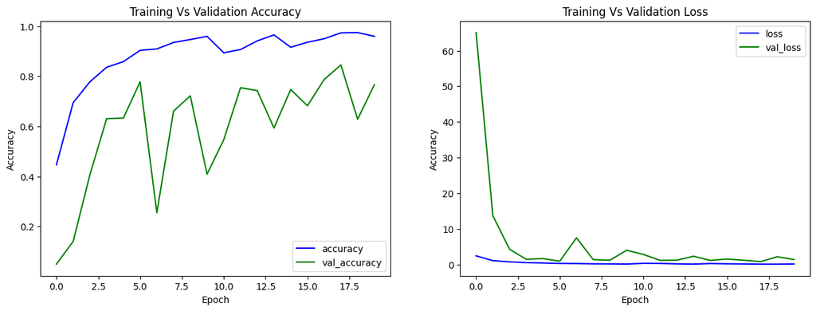

```python
# Analysis the results
fig, (ax1,ax2) = plt.subplots(1,2, figsize=(15,5))

# plot training vs validation accuracy
ax1.plot(np.arange(0,20), history_data_augumented.history['accuracy'], label='accuracy', color='blue')
ax1.plot(np.arange(0,20), history_data_augumented.history['val_accuracy'], label='val_accuracy', color='green')
ax1.set_title('Training Vs Validation Accuracy')
ax1.set_xlabel('Epoch')
ax1.set_ylabel('Accuracy')
ax1.legend(loc='lower right')

# plot training vs validation loss
ax2.plot(np.arange(0,20), history_data_augumented.history['loss'], label='loss', color='blue')
ax2.plot(np.arange(0,20), history_data_augumented.history['val_loss'],label='val_loss', color='green')
ax2.set_title('Training Vs Validation Loss')
ax2.set_xlabel('Epoch')
ax2.set_ylabel('Accuracy')
ax2.legend()

plt.show();
```